# Data Exploration Project

Jonathan Burns

2022-08-08

```r
knitr::opts_chunk$set(echo = TRUE)
knitr::opts_knit$set(root.dir = rprojroot::find_rstudio_root_file())
library(tidyverse)
library(purrr)
library(lubridate)
library(fixest)
```

## Gather and manipulate data

### Read trend files from project directory

```r
files <- list.files("data", full.names=TRUE, pattern = "^trends_up_to_")
gtrends_df <- map_df(files, read_csv)
```

### Clean and aggregate data

```r
gtrends_df <- gtrends_df %>%
  mutate(mow_transf = str_sub(gtrends_df$monthorweek, 1, 10)) %>%
  mutate(date = ymd(mow_transf)) %>%
  mutate(month = floor_date(date, unit = 'month'))

gtrends_df <- gtrends_df %>%
  group_by(schname, keyword) %>%
  mutate(stand_index = (index - mean(index)/sd(index))) %>%
  filter(!is.na(stand_index))

mth_agg <- gtrends_df %>%
  group_by(schname, month) %>%
  summarize(stand_index)
```

### Read in scorecard data

```r
scorecard <- read_csv("data/Most+Recent+Cohorts+(Scorecard+Elements).csv")
id_to_name <- read_csv("data/id_name_link.csv")
```

### Merge scorecard data into main data frame

First, remove duplicate schools from id_to_name data frame. Then, join data frames.

```r
id_to_name <- id_to_name %>%
  group_by(schname) %>%
  mutate(n = n()) %>%
  filter(n == 1)

full_trends_df <- inner_join(gtrends_df, id_to_name)
full_trends_df <- inner_join(full_trends_df, scorecard, by = c("unitid" = "UNITID"))

month_trends_df <- inner_join(mth_agg, id_to_name)
month_trends_df <- inner_join(month_trends_df, scorecard, by = c("unitid" = "UNITID"))
```

## Research question

The College Scorecard was released at the start of September 2015. Among colleges that predominantly grant bachelor’s degrees, did the release of the Scorecard shift student interest to high-earnings colleges relative to low-earnings ones (as proxied by Google searches for keywords associated with those colleges)?

### Analysis of data

We may want to consider the monthly data - weekly data (especially for smaller schools) can be volatile, so monthly data should help smooth trends out. However, it’s a bit early to decide on that, so we’ll duplicate the following steps on both. Additionally, we’ve completely abandoned the “keyword” field because we’re interested in the association with the school - not the specific syntax in the Google searches.

Based on the research question, it’s clear some more data manipulation is necessary.

First, filter out rows without income data, and convert remaining to numeric values.

```r
full_trends_df <- full_trends_df[!is.na(as.numeric(full_trends_df$`md_earn_wne_p10-REPORTED-EARNINGS`)), ]
full_trends_df <- full_trends_df %>%
  mutate(md_earn_10 = as.numeric(`md_earn_wne_p10-REPORTED-EARNINGS`))

month_trends_df <- month_trends_df[!is.na(as.numeric(month_trends_df$`md_earn_wne_p10-REPORTED-EARNINGS`)), ]
month_trends_df <- month_trends_df %>%
  mutate(md_earn_10 = as.numeric(`md_earn_wne_p10-REPORTED-EARNINGS`))
```

Using the scorecard data, we will assign 3 categories for colleges, based on the mean earnings of students 10 years after entry:

low: less than mean(md_earn_wne_p10) - 0.67 * sd(md_earn_wne_p10) med: within mean(md_earn_wne_p10) +/- 0.67 * sd(md_earn_wn_p10) high: greater than mean(md_earn_wne_p10) + 0.67 * sd(md_earn_wn_p10)

This filter approximates the bottom and top quartiles of the population, but uses the standard deviation to find these quartiles to help smooth out any idiosyncrasies in the sample data.

Finally, we’ll filter to high/low to focus on our test data.

```r
low <- mean(full_trends_df$md_earn_10) - 0.67 * sd(full_trends_df$md_earn_10)
high <- mean(full_trends_df$md_earn_10) + 0.67 * sd(full_trends_df$md_earn_10)

full_trends_df <- full_trends_df %>%
  mutate(earnings_bracket = case_when(md_earn_10 < low ~ "low",
                                      md_earn_10 > high ~ "high",
                                      TRUE ~ "med"))

full_trends_df %>%
  group_by(earnings_bracket) %>%
  distinct(schname) %>%
  count()
```

```
## # A tibble: 3 x 2
## # Groups:   earnings_bracket [3]
##   earnings_bracket     n
##   <chr>            <int>
## 1 high               460
## 2 low                810
## 3 med               1409
```

```r
full_hi_lo_df <- filter(full_trends_df, earnings_bracket != "med")

# monthly starts here

low <- mean(month_trends_df$md_earn_10) - 0.67 * sd(month_trends_df$md_earn_10)
high <- mean(month_trends_df$md_earn_10) + 0.67 * sd(month_trends_df$md_earn_10)

month_trends_df <- month_trends_df %>%
  mutate(earnings_bracket = case_when(md_earn_10 < low ~ "low",
                                      md_earn_10 > high ~ "high",
                                      TRUE ~ "med"))

month_trends_df %>%
  group_by(earnings_bracket) %>%
  distinct(schname) %>%
  count()
```

```
## # A tibble: 3 x 2
## # Groups:   earnings_bracket [3]
##   earnings_bracket     n
##   <chr>            <int>
## 1 high               460
## 2 low                810
## 3 med               1409
```

```r
mth_hi_lo_df <- filter(month_trends_df, earnings_bracket != "med")
```

### Data visualization

Before conducting any modeling, we should observe the data and see if we can make any initial decisions about the appropriate analysis. We’ll average over high/low earnings brackets to help chart the data better.

```r
exp_df <- full_hi_lo_df %>%
  group_by(earnings_bracket, date) %>%
  summarize(stand_index = mean(stand_index))
```

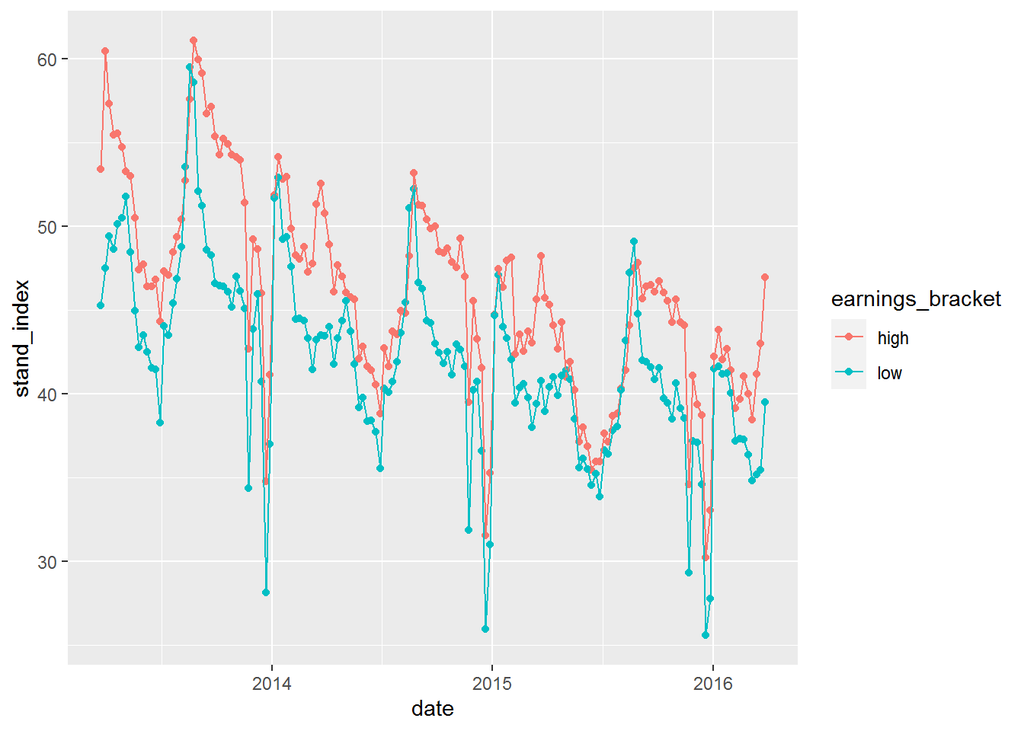

```r
ggplot(data = exp_df, aes(date, stand_index, colour = earnings_bracket)) +
  geom_point() +
  geom_line()
```

```r
mth_exp_df <- mth_hi_lo_df %>%
  group_by(earnings_bracket, month) %>%
  summarize(mth_index = mean(stand_index))
```

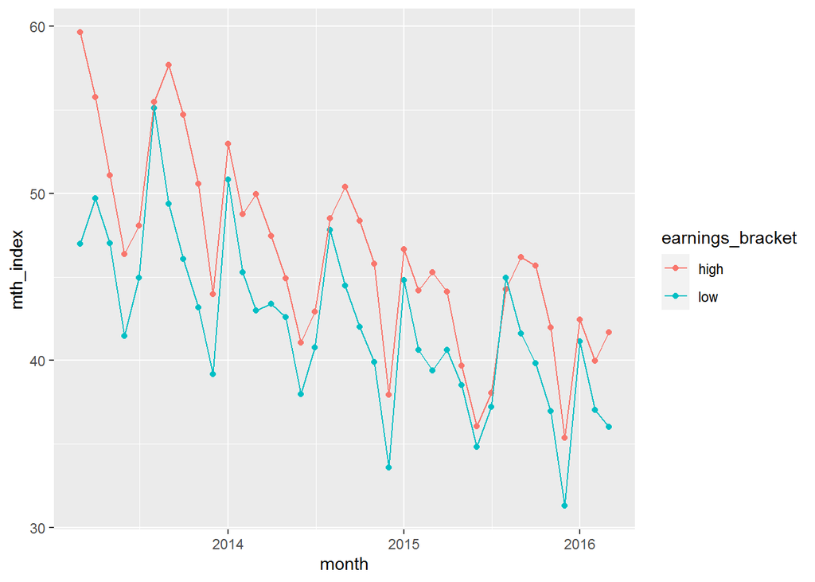

```r
ggplot(data = mth_exp_df, aes(month, mth_index, colour = earnings_bracket)) +
  geom_point() +
  geom_line()
```

Based on these graphs, the weekly data looks like it captures the trends well, but there is a seasonal impact. What if we compare the difference between the index on a weekly basis?

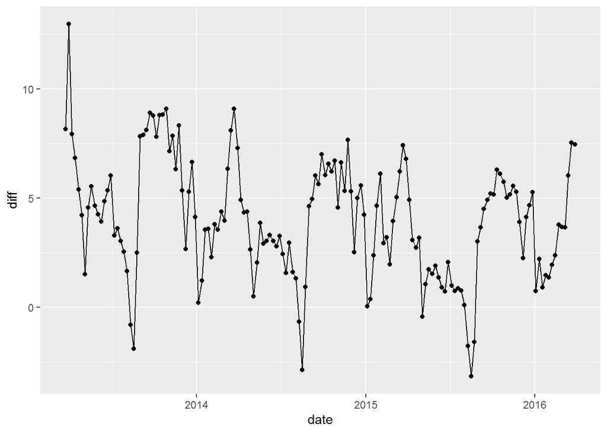

```r
exp_df <- exp_df %>%
  mutate(high = ifelse(earnings_bracket == 'high', stand_index, 0)) %>%
  mutate(low = ifelse(earnings_bracket == 'low', stand_index, 0))

diff_df <- exp_df %>%
  group_by(date) %>%
  summarize(diff = max(high) - max(low))

ggplot(data = diff_df, aes(date, diff)) +
  geom_point() +
  geom_line()
```

I think there’s some more space to explore here, but I’m not seeing anything blatantly obvious, and we’re moving into crunch time so I’ll proceed with what I have on a weekly basis.

### Actually the analysis

Using the weekly data, we’ll conduct a difference-in-differences analysis, treating the high earnings colleges as the treated sample and the low earnings colleges as the untreated sample. The reason we’re using these “treated” classifications is because we’re assuming the scorecard brings more attention to a high-income university.

```r
full_hi_lo_df <- full_hi_lo_df %>%
  mutate(treated = earnings_bracket == "high") %>%
  mutate(post_treatment = date >= as.Date("2015-09-01"))

college_did <- feols(stand_index ~ treated * post_treatment, data = full_hi_lo_df)

etable(college_did)
```

```
##                                         college_did
## Dependent Var.:                         stand_index
##
## (Intercept)                       43.00*** (0.0399)
## treatedTRUE                       3.953*** (0.0606)
## post_treatmentTRUE               -5.196*** (0.0915)
## treatedTRUE x post_treatmentTRUE    0.1676 (0.1393)
## ________________________________ __________________
## S.E. type                                       IID
## Observations                                528,971
## R2                                          0.02014
## Adj. R2                                     0.02013
## ---
## Signif. codes: 0 '***' 0.001 '**' 0.01 '*' 0.05 '.' 0.1 ' ' 1
```

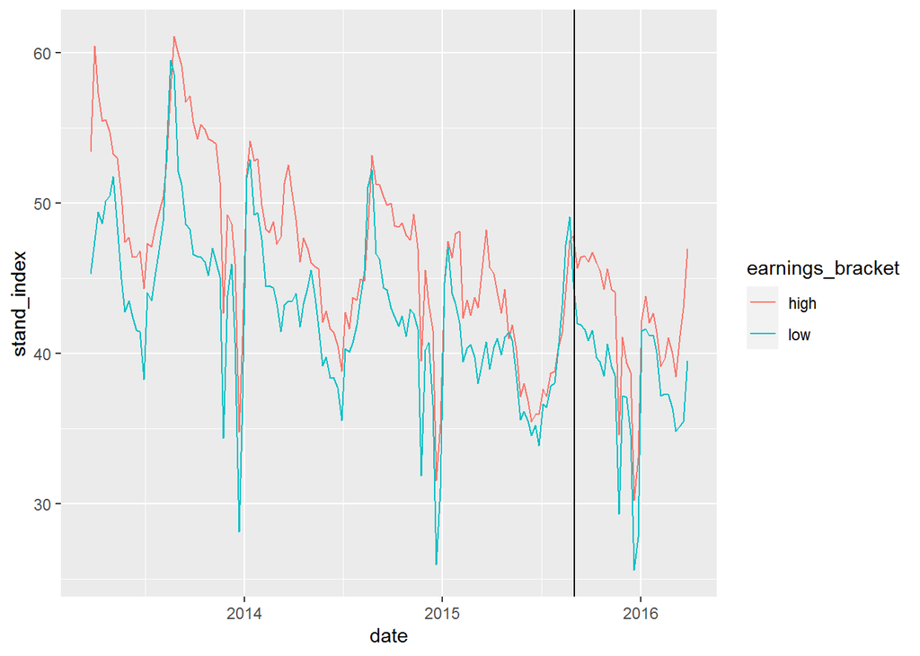

```r
# same graph as before to look at the difference

ggplot(exp_df, aes(x = date, y = stand_index, colour = earnings_bracket)) +
  geom_line() +
  geom_vline(xintercept = as.Date("2015-09-01"))
```

Let’s also add fixed effects for month, since we see seasonal effects:

```r
college_did_adv <- feols(stand_index ~ treated * post_treatment | month, data = full_hi_lo_df)
```

```
## The variable 'post_treatmentTRUE' has been removed because of collinearity (see $collin.var).
```

```r
etable(college_did, college_did_adv)
```

```
##                                         college_did   college_did_adv
## Dependent Var.:                         stand_index       stand_index
##
## (Intercept)                       43.00*** (0.0399)
## treatedTRUE                       3.953*** (0.0606) 3.938*** (0.4714)
## post_treatmentTRUE               -5.196*** (0.0915)
## treatedTRUE x post_treatmentTRUE    0.1676 (0.1393)   0.1711 (0.7699)
## Fixed-Effects:                   ------------------ -----------------
## month                                            No               Yes
## ________________________________ __________________ _________________
## S.E. type                                       IID         by: month
## Observations                                528,971           528,971
## R2                                          0.02014           0.07346
## Within R2                                        --           0.01048
## ---
## Signif. codes: 0 '***' 0.001 '**' 0.01 '*' 0.05 '.' 0.1 ' ' 1
```

## Conclusion

In the first model, there is a downward trend in search term interest after the treatment date. Based on the standardization, for low-earning schools, there is a 5.2-standard-deviation decrease in search interest for those schools. However, high-earning schools have a positive influence of 3.9-standard-deviations. Both of these values are significant at the 0.05 level, but the difference post- treatment for high-earning schools is not significant.

By adding “month” as a fixed effect, we find that the only significant factor is simply being a high-earning school. Independent of the treatment date, these schools saw an increase in search interest of 3.9 standard deviations.

Based on this analysis, we would accept the null hypothesis that the scorecard had no impact on search interest between high- and low-earning schools, as defined in this study. I other words, high-earning schools have a higher search interest by 3.9 standard deviations when compared to low-earning schools, and this effect is not impacted by the publication of the college scorecard.

Given the limited post-scorecard dataset, this analysis should be conducted with a broader data set when additional dates are available. There may be a delay in impact due to the timing of the scorecard release, and multiple years post-treatment will help expose any relevant trends.